# Propensity Score Matching

Maestría en Economía Uninorte

Author

Carlos Andrés Yanes

Published

August 23, 2024

# Introducción

Seguimos trabajando el *ejemplo* de Nessa, Ali, and Abdul-Hakim (2012) para el análisis del impacto Programa de Microcréditos[^1] realizado en Bangladesh para 1998.

<sup>1</sup> Esto se hizo gracias al libro de Evaluación de Impacto en la Practica del Banco Mundial y la parte de R fue construida por [John Woodill](https://johnwoodill.github.io/)

Las variables son: Código hogar (nh); año (year); código de la villa (villid); Código zona (thanaid); Edad del jefe (agehead); Sexo(sexhead); Educación “en años” del jefe (educhead), tamaño de la familia (famsize); Tierra(hhland); Activos del jefe (hhasset); Gasto anual en comida (expfd); gasto anual en elementos distintos a la comida (expnfd); gasto total per capita al año (exptot); Si el hombre tiene un microcredito (dmmfd); Si la mujer tiene un microcrédito (dfmfd); Peso muestral (weight); Acceso del pueblo a una carretera (vaccess); proporcion de la tierra que ha sido regado (pcirr); Precios de alimentos como aceite, arroz, trigo, leche, papa, huevos.

## Preparación del entorno de trabajo

Cerciorese primero de tener un entorno adecuado de paquetes para trabajar el archivo o base de datos. Si debe instalar alguno no olvide utilizar p.e:

```r
install.packages(c("pacman", "survey" "haven", "tidyverse", "huxtable"))
```

Despues que culmine la instalación, carguelos con la opción de `library()`

```r
library(pacman)
p_load(survey, foreign, haven, tidyverse, huxtable, dplyr, Matching, MatchIt, ggplot2)
```

Sigue el cargue de los datos, *debe cerciorarse que esten en su carpeta de trabajo*

```r
hh_98 <- read_dta("hh_98.dta")
head(hh_98) # Encabezado
```

| nh | year | villid | thanaid | agehead | sexhead | educhead | famsize | hhland | hhasset | expfd | expnfd | exptot | dmmfd | dfmfd | weight | vaccess | pcirr | rice | wheat | milk | potato | egg | oil |
| --- | --- | --- | --- | --- | --- | --- | --- | --- | --- | --- | --- | --- | --- | --- | --- | --- | --- | --- | --- | --- | --- | --- | --- |
| 1.11e+04 | 1 | 1 | 1 | 79 | 1 | 0 | 2 | 36 | 3.33e+04 | 8.26e+03 | 1.24e+03 | 9.5e+03 | 0 | 1 | 1.04 | 1 | 0.45 | 12.6 | 8.12 | 11.5 | 8.55 | 2.2 | 40.6 |
| 1.11e+04 | 1 | 1 | 1 | 43 | 1 | 6 | 4 | 116 | 1.8e+05 | 6.72e+03 | 1.25e+04 | 1.92e+04 | 1 | 1 | 1.01 | 1 | 0.45 | 12.6 | 8.12 | 11.5 | 8.55 | 2.2 | 40.6 |
| 1.11e+04 | 1 | 1 | 1 | 52 | 0 | 0 | 7 | 91 | 8.07e+04 | 5.11e+03 | 2.39e+03 | 7.51e+03 | 0 | 1 | 1.01 | 1 | 0.45 | 12.6 | 8.12 | 11.5 | 8.55 | 2.2 | 40.6 |
| 1.11e+04 | 1 | 1 | 1 | 48 | 1 | 0 | 7 | 8 | 1.68e+04 | 4.08e+03 | 1.25e+03 | 5.33e+03 | 0 | 1 | 1.01 | 1 | 0.45 | 12.6 | 8.12 | 11.5 | 8.55 | 2.2 | 40.6 |
| 1.2e+04 | 1 | 2 | 1 | 35 | 1 | 10 | 5 | 10 | 1.88e+04 | 7.03e+03 | 1.76e+04 | 2.47e+04 | 0 | 1 | 0.763 | 1 | 0.2 | 10.2 | 6.09 | 10.8 | 6.87 | 2.03 | 43.3 |
| 1.2e+04 | 1 | 2 | 1 | 33 | 1 | 5 | 7 | 16 | 4.49e+04 | 2.11e+03 | 1.17e+03 | 3.28e+03 | 0 | 0 | 2.25 | 1 | 0.2 | 10.2 | 6.09 | 10.8 | 6.87 | 2.03 | 43.3 |

Mas adelante de ver nuestra base, creamos un par de variables en términos logarítmicos

```r
hh_98.data <- mutate(hh_98, lexptot = log(1 + exptot)) %>%
  mutate(lnland = log((1 + hhland/100)))
```

## Impacto de la participación del programa

Vamos a tomar la base de datos de forma no balanceada, para ello con la opción del paquete de `survey` lo tomamos

```r
des1 <- svydesign(id = ~nh,  weights = ~weight, data = hh_98.data)

# Modelo probit dependiente la participación
prog.lm <- svyglm(dmmfd ~ sexhead + agehead + educhead + lnland + vaccess + pcirr + rice + wheat + milk + oil + egg,
                  design=des1, family = quasibinomial(link = "probit"))

# Lista de variables
X <- prog.lm$fitted
Tr <- hh_98.data$dmmfd
Y <- hh_98.data$lexptot

# Matching
m.out <- Match(Tr = Tr, X = X, Y = Y, caliper = 0.001)
summary(m.out)
```

```
Estimate...  -0.081316
AI SE......  0.031365
T-stat.....  -2.5926
p.val......  0.0095266

Original number of observations..............  1129
Original number of treated obs...............  220
Matched number of observations...............  71
Matched number of observations  (unweighted).  88

Caliper (SDs)........................................   0.001
Number of obs dropped by 'exact' or 'caliper'  149
```

Podemos ver que existe una diferencia significativa del efecto con el grupo. Teniendo como dependiente el gasto anual de los campesinos.

## Primer Match

Ahora vamos a mirar como podemos buscar la relación de matching entre individuos a partir de las características observables dentro de la muestra

```r
MatchBalance(dmmfd ~ sexhead + agehead + educhead + lnland + vaccess + pcirr + rice + wheat + milk + oil + egg, data = hh_98.data, nboots = 500, ks = TRUE)
```

```
***** (V1) sexhead *****
before matching:
mean treatment........ 0.97727
mean control.......... 0.89109
std mean diff......... 57.697

mean raw eQQ diff..... 0.086364
med  raw eQQ diff..... 0
max  raw eQQ diff..... 1

mean eCDF diff........ 0.043092
med  eCDF diff........ 0.043092
max  eCDF diff........ 0.086184

var ratio (Tr/Co)..... 0.22965
T-test p-value........ 3.6741e-09


***** (V2) agehead *****
before matching:
mean treatment........ 44.036
mean control.......... 46.491
std mean diff......... -20.891

mean raw eQQ diff..... 2.7727
med  raw eQQ diff..... 3
max  raw eQQ diff..... 15

mean eCDF diff........ 0.042981
med  eCDF diff........ 0.030478
max  eCDF diff........ 0.12168

var ratio (Tr/Co)..... 0.83529
T-test p-value........ 0.0066778
KS Bootstrap p-value.. 0.004
KS Naive p-value...... 0.010544
KS Statistic.......... 0.12168


***** (V3) educhead *****
```

[output cut: 172 more lines]

```
max  raw eQQ diff..... 0.50751

mean eCDF diff........ 0.083573
med  eCDF diff........ 0.077308
max  eCDF diff........ 0.14831

var ratio (Tr/Co)..... 0.82698
T-test p-value........ 1.935e-06
KS Bootstrap p-value.. < 2.22e-16
KS Naive p-value...... 0.00082542
KS Statistic.......... 0.14831


Before Matching Minimum p.value: < 2.22e-16
Variable Name(s): egg  Number(s): 11
```

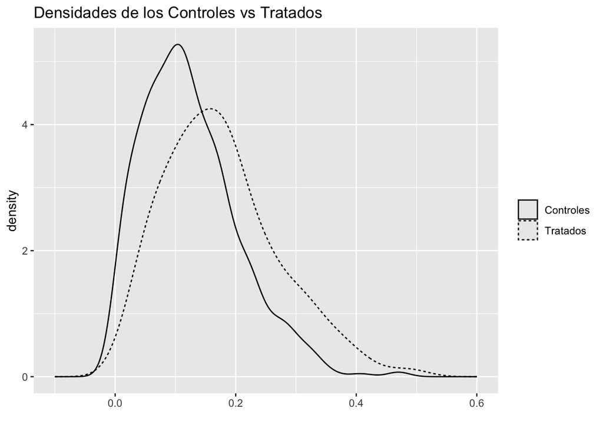

```r
fit <- prog.lm$data
fit$fvalues <- prog.lm$fitted.values

fit.control <- filter(fit, dmmfd == 0)
fit.treated <- filter(fit, dmmfd == 1)

ggplot() +
  geom_density(aes(x=fit.control$fvalues, linetype = '2')) +
  geom_density(aes(x=fit.treated$fvalues, linetype = '3')) +
  xlim(-.1,.6) +
  xlab("") +
  scale_linetype_discrete(name = "", labels = c("Controles", "Tratados")) +
  ggtitle("Densidades de los Controles vs Tratados")
```

## Segunda regresión pero con balance

A continuación intentamos replicar lo anterior, pero ya mas balanceado en el grupo de controles

```r
# Second Regression (Balanced)

des1 <- svydesign(id = ~nh,  weights = ~weight, data = hh_98.data)
prog.lm <- svyglm(dmmfd ~ sexhead + agehead + educhead + lnland + vaccess + pcirr + rice + wheat + milk + oil,
                  design=des1, family = quasibinomial(link = "probit"))

X <- prog.lm$fitted
Tr <- hh_98.data$dmmfd
Y <- hh_98.data$lexptot

# Acá ya existe como tal la zona de soporte común
m.out <- Match(Tr = Tr, X = X, Y = Y, caliper = 0.001, M = 1, CommonSupport = TRUE)
summary(m.out)
```

```
Estimate...  -0.025275
AI SE......  0.030279
T-stat.....  -0.83474
p.val......  0.40387

Original number of observations..............  1084
Original number of treated obs...............  219
Matched number of observations...............  76
Matched number of observations  (unweighted).  106

Caliper (SDs)........................................   0.001
Number of obs dropped by 'exact' or 'caliper'  143
```

## Vamos al grafico

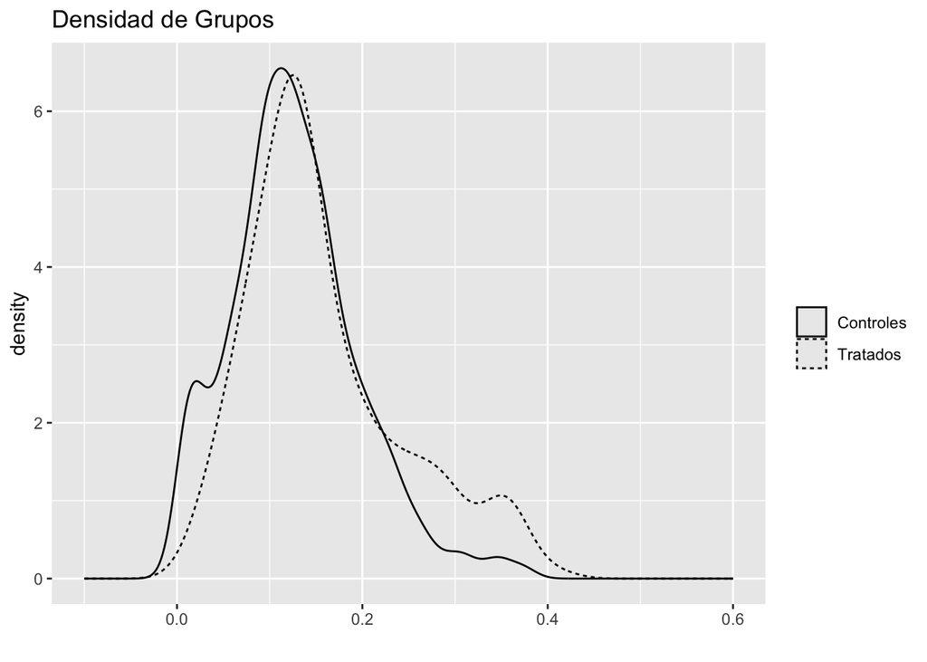

```r
fit <- prog.lm$data
fit$fvalues <- prog.lm$fitted.values

fit.control <- filter(fit, dmmfd == 0)
fit.treated <- filter(fit, dmmfd == 1)

ggplot() +
  geom_density(aes(x=fit.control$fvalues, linetype = '2')) +
  geom_density(aes(x=fit.treated$fvalues, linetype = '3')) +
  xlim(-.1,.6) +
  xlab("") +
  scale_linetype_discrete(name = "", labels = c("Controles", "Tratados")) +
  ggtitle("Densidad de Grupos")
```

## Vecino cercano

En esta parte tomaremos por grupos e iremos viendo otras opciones

```r
# Nearest Neighbor
des1 <- svydesign(id = ~nh,  weights = ~weight, data = hh_98.data)
prog.lm <- svyglm(dmmfd ~ sexhead + agehead + educhead + lnland + vaccess + pcirr + rice + wheat + milk + oil,
                  design=des1, family = quasibinomial(link = "probit"))

X <- prog.lm$fitted.values
Tr <- hh_98.data$dmmfd
Y <- hh_98.data$lexptot
m.out <- Match(Tr = Tr, X = X, Y = Y, M = 1, caliper = 0.001, replace = TRUE)
summary(m.out)
```

```
Estimate...  -0.028309
AI SE......  0.0301
T-stat.....  -0.94049
p.val......  0.34696

Original number of observations..............  1129
Original number of treated obs...............  220
Matched number of observations...............  79
Matched number of observations  (unweighted).  109

Caliper (SDs)........................................   0.001
Number of obs dropped by 'exact' or 'caliper'  141
```

### Usando MatchIt

Vamos a implementar ahora el paquete de `MatchIt` para mirar otras opciones de pareo.

```r
# Este es estratificando
m.out <- matchit(dmmfd ~ sexhead + agehead + educhead + lnland + vaccess + pcirr + rice + wheat + milk + oil,
                 data = hh_98.data, method = "nearest", distance = "probit", caliper = 0.001)
summary(m.out)
```

```
Call:
matchit(formula = dmmfd ~ sexhead + agehead + educhead + lnland +
    vaccess + pcirr + rice + wheat + milk + oil, data = hh_98.data,
    method = "nearest", distance = "probit", caliper = 0.001)

Summary of Balance for All Data:
         Means Treated Means Control Std. Mean Diff. Var. Ratio eCDF Mean
distance        0.2243        0.1877          0.5302     0.8132    0.1305
sexhead         0.9773        0.8911          0.5783          .    0.0862
agehead        44.0364       46.4906         -0.2089     0.8353    0.0430
educhead        2.7409        2.2145          0.1434     1.1516    0.0345
lnland          0.3243        0.3916         -0.1700     0.5617    0.0346
vaccess         0.8500        0.8317          0.0513          .    0.0183
pcirr           0.5532        0.5621         -0.0252     1.1482    0.0266
rice           10.5316       10.2228          0.1731     1.4065    0.0513
wheat           7.5296        7.4517          0.1006     0.8055    0.0344
milk           10.6085       10.9654         -0.1070     0.9682    0.0284
oil            39.4259       39.3979          0.0064     1.2295    0.0218
         eCDF Max
distance   0.1896
sexhead    0.0862
agehead    0.1217
educhead   0.0790
lnland     0.0639
vaccess    0.0183
pcirr      0.0528
rice       0.1258
wheat      0.0756
milk       0.0861
oil        0.0531

Summary of Balance for Matched Data:
         Means Treated Means Control Std. Mean Diff. Var. Ratio eCDF Mean
distance        0.2060        0.2060          0.0001     1.0002    0.0009
sexhead         0.9888        0.9775          0.0754          .    0.0112
agehead        44.0787       45.2247         -0.0976     0.8521    0.0298
educhead        2.0787        2.0674          0.0031     1.1143    0.0142
lnland          0.3467        0.2833          0.1602     0.9305    0.0533
vaccess         0.9101        0.9213         -0.0315          .    0.0112
pcirr           0.5412        0.5534         -0.0349     1.2947    0.0484
```

[output cut: 8 more lines]

```
educhead   0.0449          0.7804
lnland     0.1798          0.9021
vaccess    0.0112          0.3461
pcirr      0.1011          1.1403
rice       0.0899          0.8277
wheat      0.1236          1.0847
milk       0.0899          1.2078
oil        0.0899          1.2075

Sample Sizes:
          Control Treated
All           909     220
Matched        89      89
Unmatched     820     131
Discarded       0       0
```

### Solo mujeres

```r
glm.female <- glm(dfmfd ~ sexhead + agehead + educhead + lnland + vaccess + pcirr + rice + wheat + milk + oil, family = binomial, data = hh_98.data)
X <- glm.female$fitted
Tr <- hh_98.data$dmmfd
Y <- hh_98.data$lexptot
m.out <- Match(Tr = Tr, X = X, Y = Y, caliper = 0.001, M = 1, replace = TRUE)
summary(m.out)
```

```
Estimate...  0.0059114
AI SE......  0.027928
T-stat.....  0.21167
p.val......  0.83237

Original number of observations..............  1129
Original number of treated obs...............  220
Matched number of observations...............  100
Matched number of observations  (unweighted).  137

Caliper (SDs)........................................   0.001
Number of obs dropped by 'exact' or 'caliper'  120
```

¿Qué nos dice esta parte?

#### Modelo adicional

```r
# Ajuste del modelo de Propensity Score
pscore_model <- matchit(dmmfd ~ sexhead + agehead + educhead + lnland + vaccess + pcirr + rice + wheat + milk + oil + egg,
                        method = "nearest", data = hh_98.data)
summary(pscore_model)
```

```
Call:
matchit(formula = dmmfd ~ sexhead + agehead + educhead + lnland +
    vaccess + pcirr + rice + wheat + milk + oil + egg, data = hh_98.data,
    method = "nearest")

Summary of Balance for All Data:
         Means Treated Means Control Std. Mean Diff. Var. Ratio eCDF Mean
distance        0.2519        0.1811          0.6523     1.2798    0.1861
sexhead         0.9773        0.8911          0.5783          .    0.0862
agehead        44.0364       46.4906         -0.2089     0.8353    0.0430
educhead        2.7409        2.2145          0.1434     1.1516    0.0345
lnland          0.3243        0.3916         -0.1700     0.5617    0.0346
vaccess         0.8500        0.8317          0.0513          .    0.0183
pcirr           0.5532        0.5621         -0.0252     1.1482    0.0266
rice           10.5316       10.2228          0.1731     1.4065    0.0513
wheat           7.5296        7.4517          0.1006     0.8055    0.0344
milk           10.6085       10.9654         -0.1070     0.9682    0.0284
oil            39.4259       39.3979          0.0064     1.2295    0.0218
egg             1.8509        1.9781         -0.3710     0.8270    0.0836
         eCDF Max
distance   0.3022
sexhead    0.0862
agehead    0.1217
educhead   0.0790
lnland     0.0639
vaccess    0.0183
pcirr      0.0528
rice       0.1258
wheat      0.0756
milk       0.0861
oil        0.0531
egg        0.1483

Summary of Balance for Matched Data:
         Means Treated Means Control Std. Mean Diff. Var. Ratio eCDF Mean
distance        0.2519        0.2503          0.0147     1.0473    0.0016
sexhead         0.9773        0.9818         -0.0305          .    0.0045
agehead        44.0364       44.2955         -0.0221     0.9099    0.0168
educhead        2.7409        2.7455         -0.0012     0.9079    0.0155
lnland          0.3243        0.3674         -0.1088     0.6618    0.0265
```

[output cut: 12 more lines]

```
lnland     0.0636          1.0476
vaccess    0.0455          0.8147
pcirr      0.0955          1.0781
rice       0.0909          0.9335
wheat      0.1182          1.1397
milk       0.1045          1.0058
oil        0.0955          1.0349
egg        0.0318          0.9035

Sample Sizes:
          Control Treated
All           909     220
Matched       220     220
Unmatched     689       0
Discarded       0       0
```

Para el objeto de extraer datos

```r
# Extraer los datos emparejados
matched_data <- match.data(pscore_model)
head(matched_data)
```

| nh | year | villid | thanaid | agehead | sexhead | educhead | famsize | hhland | hhasset | expfd | expnfd | exptot | dmmfd | dfmfd | weight | vaccess | pcirr | rice | wheat | milk | potato | egg | oil | lexptot | lnland | distance | weights | subclass |
| --- | --- | --- | --- | --- | --- | --- | --- | --- | --- | --- | --- | --- | --- | --- | --- | --- | --- | --- | --- | --- | --- | --- | --- | --- | --- | --- | --- | --- |
| 1.11e+04 | 1 | 1 | 1 | 43 | 1 | 6 | 4 | 116 | 1.8e+05 | 6.72e+03 | 1.25e+04 | 1.92e+04 | 1 | 1 | 1.01 | 1 | 0.45 | 12.6 | 8.12 | 11.5 | 8.55 | 2.2 | 40.6 | 9.86 | 0.77 | 0.231 | 1 | 21 |
| 1.11e+04 | 1 | 1 | 1 | 48 | 1 | 0 | 7 | 8 | 1.68e+04 | 4.08e+03 | 1.25e+03 | 5.33e+03 | 0 | 1 | 1.01 | 1 | 0.45 | 12.6 | 8.12 | 11.5 | 8.55 | 2.2 | 40.6 | 8.58 | 0.077 | 0.23 | 1 | 90 |
| 1.3e+04 | 1 | 3 | 1 | 35 | 1 | 0 | 4 | 138 | 8.41e+04 | 3.67e+03 | 2.48e+03 | 6.15e+03 | 0 | 1 | 1.49 | 0 | 0.75 | 9.02 | 6.09 | 10.8 | 6.11 | 2.03 | 40.6 | 8.72 | 0.867 | 0.0844 | 1 | 119 |
| 1.3e+04 | 1 | 3 | 1 | 48 | 1 | 0 | 4 | 237 | 6.47e+05 | 4.79e+03 | 2.2e+03 | 6.99e+03 | 0 | 1 | 1.49 | 0 | 0.75 | 9.02 | 6.09 | 10.8 | 6.11 | 2.03 | 40.6 | 8.85 | 1.21 | 0.0626 | 1 | 13 |
| 1.31e+04 | 1 | 3 | 1 | 70 | 1 | 0 | 4 | 19 | 3.4e+04 | 3.26e+03 | 6.08e+03 | 9.34e+03 | 1 | 0 | 0.657 | 0 | 0.75 | 9.02 | 6.09 | 10.8 | 6.11 | 2.03 | 40.6 | 9.14 | 0.174 | 0.0767 | 1 | 22 |
| 1.31e+04 | 1 | 3 | 1 | 41 | 1 | 0 | 5 | 3 | 4.24e+03 | 2.4e+03 | 523 | 2.93e+03 | 1 | 0 | 0.657 | 0 | 0.75 | 9.02 | 6.09 | 10.8 | 6.11 | 2.03 | 40.6 | 7.98 | 0.0296 | 0.113 | 1 | 24 |

**Carlos Yanes Guerra | Departamento de Economía | Universidad del Norte**